# Getting Started with terradish

Bill Peterman

## 1 What is terradish for?

`terradish` estimates conditional associations between raster covariates (altitude, forest cover, roads, water bodies, etc.) and genetic distance or covariance among sampled populations.

The core idea is **isolation by resistance (IBR)**: instead of assuming that genetic distance simply tracks straight-line geographic distance (isolation by distance, IBD), IBR represents the landscape as a heterogeneous graph. Each cell has a fitted **conductance**, and neighboring cells define weighted edges. Conductance is a relative model quantity, not a direct observation of movement, migration, habitat suitability, or permeability.

If we can map conductance across the landscape as a function of measurable covariates (rasters), we can:

1. Build a **conductance surface**: a weighted graph over the raster grid.
2. Build the weighted graph Laplacian $L(\theta)$ and its generalized inverse $E(\theta)=L(\theta)^+$.
3. Derive resistance distances from $E(\theta)$ when the measurement model requires them.
4. Link $E(\theta)$ or its resistance distances to an observed genetic matrix with a selected measurement likelihood.
5. Optimize the conductance and nuisance parameters by maximum likelihood.

Version 1.0.0 focuses on symmetric resistance models with log-linear, fixed-degree spline, or jointly estimated Gaussian-scale conductance. Environmental differences between sites can enter either MLPE or Wishart measurement models. Directional, selected-pair, hierarchical, and other experimental extensions are maintained on the `experimental` branch.

`terradish` automates these steps and provides gradients, standard errors, model-comparison tools, and visualization helpers.

## 2 A conceptual road map

Before writing any code, it helps to see how the pieces fit together:

```
Raster covariates                   Sampling locations
(altitude, forestcover)             (GPS coordinates)
        |                                  |
        +-----> conductance_surface() <----+
                        |   (builds the weighted graph)
                        v
             conductance model -> L(theta) -> E(theta)
                         v
              measurement model  <-- distance or covariance likelihood
                        v
                   fitted model
                   coef(), summary(), fitted(),
                   conductance(), anova()
```

The **conductance model** maps raster values at each grid cell to a conductance value. `loglinear_conductance` is the default: conductance = $\exp(\theta_1 x_{i,\mathrm{altitude}} + \theta_2 x_{i,\mathrm{forestcover}} + \cdots)$. The parameters $\theta$ are what we estimate.

The **measurement model** links the graph to the observed genetic summary. For pairwise genetic distances, `mlpe` accounts for a shared-site component of dependence; `leastsquares` assumes independent errors. For a suitably constructed covariance matrix or its corresponding squared-distance matrix, the Wishart models use a likelihood on site contrasts. The response construction and inferential assumptions determine which family is appropriate. A Wishart fit also requires an analyst-supplied effective degrees of freedom, `nu`.

## 3 Installation

```r
# Released version
install.packages("terradish")

# Development version
remotes::install_github("wpeterman/terradish")
```

No other package is required. `terradish` implements the MLPE measurement model itself, so you do not need `corMLPE`. One optional package, `adegenet`, is used only by `pca_dist()` for turning `genind` genotype objects into a distance matrix; install it if you need that helper.

```r
install.packages("adegenet")
```

## 4 Load the package and example data

```r
library(terradish)
library(terra)
```

`terradish` ships with example data from a study of *Melipona* bees in Brazil. Load everything with one call:

```r
data(melip)

# The rasters are stored as "packed" objects to comply with CRAN policy;
# unwrap() converts them back to usable SpatRaster / SpatVector objects.
melip.altitude    <- terra::unwrap(melip.altitude)
melip.forestcover <- terra::unwrap(melip.forestcover)
melip.coords      <- terra::unwrap(melip.coords)
```

What do we have?

- **`melip.altitude`**: a raster of altitude across the study area, already rescaled to roughly the unit interval rather than left in meters.
- **`melip.forestcover`**: a raster of forest cover proportion (0-1).
- **`melip.coords`**: 37 sampling locations as a `SpatVector`.
- **`melip.Fst`**: a 37 x 37 matrix of pairwise F<sub>ST</sub> (a standard measure of genetic differentiation; larger values mean more differentiation).

```r
# How many sampling sites?
nrow(melip.coords)
```

```
#> [1] 37
```

```r
# Quick look at the genetic distance matrix
# (only the first 5 x 5 block for readability)
round(melip.Fst[1:5, 1:5], 3)
```

```
#>       [,1]  [,2]  [,3]  [,4]  [,5]
#> [1,] 0.000 0.009 0.104 0.048 0.075
#> [2,] 0.009 0.000 0.109 0.049 0.078
#> [3,] 0.104 0.109 0.000 0.052 0.066
#> [4,] 0.048 0.049 0.052 0.000 0.038
#> [5,] 0.075 0.078 0.066 0.038 0.000
```

F<sub>ST</sub> is symmetric (the differentiation between site A and site B is the same as between B and A), so only the lower triangle carries new information.

## 5 Visualize the spatial data

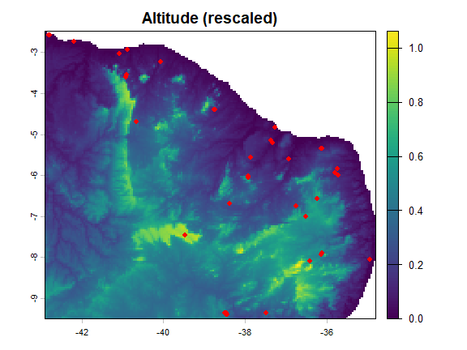

*Altitude raster with sampling sites.*

```r
plot(melip.altitude, main = "Altitude (rescaled)")
points(melip.coords, pch = 19, cex = 0.8, col = 'red')
```

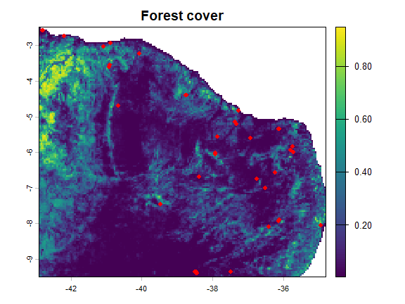

*Forest cover raster (0 = no forest, 1 = full cover).*

```r
plot(melip.forestcover, main = "Forest cover")
points(melip.coords, pch = 19, cex = 0.8, col = 'red')
```

## 6 Scale your rasters: an important step

Conductance in the loglinear model is $\exp(\boldsymbol{\theta}^{\mathsf T}\mathbf{x})$. If `x` (e.g. altitude in meters) has a very large range, small changes in $\theta$ produce enormous changes in conductance, making optimization numerically unstable. **Always scale continuous covariates** before fitting.

```r
covariates <- c(melip.altitude, melip.forestcover)
names(covariates) <- c("altitude", "forestcover")
covariates <- scale_covariates(covariates)
```

By default, `scale_covariates()` subtracts each layer’s mean and divides by its standard deviation, giving every continuous covariate a mean of 0 and a standard deviation of 1. It also stores the original-scale center and scale for each layer, which lets `plot(fit, type = "marginal", data = surface)` label x-axes in the original units automatically.

## 7 Build the conductance surface

```r
surface <- conductance_surface(covariates, melip.coords, directions = 8)
```

`conductance_surface()` does three things:

1. Reads the raster values at every non-NA grid cell.
2. Identifies which cells correspond to the sampling locations.
3. Builds a graph where adjacent cells (here, using all 8 neighbors including diagonals) are connected by edges whose weights will be determined by the conductance model.

`directions = 8` is the default; it allows diagonal movement and is less sensitive to grid orientation than `directions = 4`.

```r
# How many grid cells are in the graph?
nrow(surface$x)
```

```
#> [1] 22443
```

```r
# The covariate data for the first few cells
head(surface$x)
```

```
#>    altitude forestcover
#> 1 -1.592517  -0.9030711
#> 2 -1.552682  -0.9030711
#> 3 -1.570628  -0.9030711
#> 4 -1.572161  -0.9030711
#> 5 -1.594662  -0.9030711
#> 6 -1.591702  -0.7727471
```

### 7.1 Optional: reduce graph size for large rasters

The example raster is small enough that we can fit directly. For larger landscapes, graph size becomes the main driver of runtime. If your sampling locations occupy only part of the raster, you can crop the raster to a buffered sampling extent before the graph is constructed:

```r
surface_cropped <- conductance_surface(
  covariates,
  melip.coords,
  directions = 8,
  saveStack = TRUE,
  crop_buffer = 0.05
)
```

The buffer is measured in the raster’s map units. In a projected raster this might be meters; in a longitude/latitude raster it is degrees. Cropping is a safe speed tool only when the cropped area still contains the landscape context needed to estimate resistance distances. A good habit is to try a few buffer widths and confirm that the fitted coefficients are stable.

Another speed option is a coarse-raster warm start. This fits the same model on aggregated rasters first, then refines the estimate on the full-resolution surface:

```r
surface_for_coarse <- conductance_surface(
  covariates,
  melip.coords,
  directions = 8,
  saveStack = TRUE
)

fit_coarse <- terradish(
  melip.Fst ~ forestcover + altitude,
  data = surface_for_coarse,
  conductance_model = loglinear_conductance,
  measurement_model = mlpe,
  approximation = "coarse_raster",
  approximation_control = list(
    factor = c(4, 2),
    exact_refine = TRUE
  )
)
```

With `exact_refine = TRUE`, the final reported model is still evaluated on the original graph. The coarse fits are only used to find better starting values.

## 8 Checking computational settings

For the small *Melipona* example the default settings run in seconds and no tuning is needed. For larger landscapes (e.g., a high-resolution raster with hundreds of thousands of graph vertices, or a spline conductance model that expands to many parameters), the right optimizer and solver can meaningfully reduce wall-clock time.

The function does **not** change any package defaults and does **not** affect parameter estimation; only the computational path differs.

```r
# saveStack = TRUE is required for the coarse-raster probe
surface_for_assess <- conductance_surface(
  covariates, melip.coords,
  directions = 8, saveStack = TRUE
)

assessment <- terradish_assess_settings(
  melip.Fst ~ forestcover + altitude,
  data              = surface_for_assess,
  conductance_model = loglinear_conductance,
  measurement_model = mlpe,
  probe_maxit       = 2,      # keep small: probes compare early-iteration cost
  coarse_probe      = TRUE,   # also time the coarse-raster warm-start path
  verbose           = TRUE    # print progress as probes run
)

# Print a full summary: graph profile, probe results, recommended settings
assessment
```

The printed output has three main parts:

```
terradish setting assessment
Graph: 22443 vertices, 88844 edges, 37 focal sites
Conductance parameters: 2

Recommended settings:
  optimizer:   newton  (fastest acceptable probe: newton_hager_zhang)
  line search: HagerZhangControl
  solver:      direct  (fastest direct solver probe: supernodal_ll + cholmod_cpp_cached)
  approximation: none  (exact full-resolution fit)

Defaults comparison: Assessment matched terradish defaults.
```

- **Graph profile**: tells you how large your problem is. A vertex count above ~50 000 is where solver choice starts to matter; above ~500 000 it is often the dominant cost.
- **Recommended settings**: the fastest combination found by the probes. `"(fastest acceptable probe: ...)"` shows which probe won and why.
- **Defaults comparison**: a one-line summary of whether the assessment recommends anything different from what `terradish()` would use by default. If it says `"Assessment matched terradish defaults"`, just call `terradish()` normally.

### 8.1 Using `$recommended` in the final fit

The `$recommended` list maps directly onto `terradish()` arguments:

```r
fit_tuned <- terradish(
  melip.Fst ~ forestcover + altitude,
  data              = surface_for_assess,
  conductance_model = loglinear_conductance,
  measurement_model = mlpe,
  optimizer         = assessment$recommended$optimizer,
  control           = assessment$recommended$control,
  solver            = assessment$recommended$solver,
  solver_control    = assessment$recommended$solver_control,
  approximation     = assessment$recommended$approximation,
  approximation_control = assessment$recommended$approximation_control
)
```

You can also inspect and edit the list before using it. For example, to override the recommended `maxit` without losing the solver recommendation:

```r
my_control <- assessment$recommended$control
my_control$maxit <- 50          # allow more iterations than the probe default

fit_tuned2 <- terradish(
  melip.Fst ~ forestcover + altitude,
  data    = surface_for_assess,
  conductance_model = loglinear_conductance,
  measurement_model = mlpe,
  optimizer      = assessment$recommended$optimizer,
  control        = my_control,
  solver         = assessment$recommended$solver,
  solver_control = assessment$recommended$solver_control
)
```

### 8.2 When assessment is most useful

| Situation | Assessment benefit |
| --- | --- |
| Graph < 10 000 vertices | Minimal; defaults usually converge in seconds |
| Graph 10 000 to 100 000 vertices | Solver benchmark often helps |
| Graph > 100 000 vertices | All three probes are worthwhile |
| Spline conductance (`df ≥ 4`) | Parameter expansion can shift optimizer recommendation from Newton to BFGS |
| Fitting many candidate models | Run assessment once, reuse `$recommended` for all fits |
| Coarse-raster approximation desired | Set `coarse_probe = TRUE` to check whether warm-start pays off |

### 8.3 Troubleshooting direct-solver failures

If a fit stops with a `CHOLMOD` warning or a `non-positive-definite reduced Laplacian` message, the direct sparse Cholesky solver could not factorize the graph at the current conductance values. This is usually a numerical or data-preparation problem rather than a genetic-distance model result.

Immediate checks:

- Confirm the raster layers used by the conductance model are finite on the retained graph cells. Missing, infinite, or extremely large values can produce unusable conductances after the exponential transform.
- Scale continuous covariates with `scale_covariates()` and start conductance parameters near zero. Very large positive or negative starts can make some graph edges effectively infinite or zero.
- Re-run `terradish_assess_settings(..., verbose = TRUE)` to inspect graph size, direct-solver settings, and the optimizer path before launching a long fit.
- While diagnosing the surface, try `solver = "auto"` or `solver = "amg"`. These paths do not fix invalid conductance values, but they can help separate a direct Cholesky factorization issue from a broader model setup problem.

## 9 Fit your first model

We will start with the simplest case: are altitude and forest cover conditionally associated with genetic differentiation through the fitted conductance model?

```r
fit_ls <- terradish(
  melip.Fst ~ forestcover + altitude,  # formula: response ~ covariates
  data              = surface,          # the conductance surface
  conductance_model = loglinear_conductance,
  measurement_model = leastsquares      # ordinary regression
)
```

The formula works like a standard R formula:

- The **left-hand side** is the matrix of observed genetic distances.
- The **right-hand side** lists which raster layers parameterize conductance.

`leastsquares` is the quickest measurement model. It treats the pairwise genetic distances as independent observations regressed on resistance distances. That is not strictly correct (measurements sharing a site are correlated), but it gives a useful exploratory or diagnostic fit.

```r
summary(fit_ls)
```

```
#> Conductance surface with 22443 vertices (37 focal) estimated by maximum likelihood
#> Call:   terradish(formula = melip.Fst ~ forestcover + altitude, data = surface,
#>     conductance_model = loglinear_conductance, measurement_model = leastsquares)
#>
#> Loglikelihood: 1959.987 (5 degrees freedom)
#> AIC: -3909.975
#>
#> Number of function calls: 22
#> Number of optimization steps: 6
#> Convergence: converged | projected gradient: 2.91e-09
#> Norm of gradient at MLE: 3.192844e-09
#>
#> Nuisance parameters (conditional on fitted conductance surface; measurement-model scale):
#>        Estimate   Std. Error  Lower 95%  Upper 95%
#> alpha  -0.052578   0.004593   -0.061581  -0.043576
#> beta    0.362328   0.010291    0.342157   0.382498
#> tau     6.885848   0.054800    6.778442   6.993253
#>
#> Coefficients:
#>             Estimate Std. Error z value Pr(>|z|)
#> forestcover  0.19970    0.03050   6.548 5.81e-11 ***
#> altitude    -0.18018    0.01523 -11.827  < 2e-16 ***
#> ---
#> Signif. codes:  0 '***' 0.001 '**' 0.01 '*' 0.05 '.' 0.1 ' ' 1
#>
#> Correlation of Coefficients:
#>          forestcover
#> altitude   0.4627673
```

**How to read the output:**

- **theta**: the conductance parameters. A positive $\theta$ for a covariate means that higher values are associated with higher fitted relative conductance, conditional on other terms and the graph. A negative $\theta$ means lower fitted relative conductance. Neither sign is a direct estimate of movement or a causal landscape effect.
- **phi**: nuisance parameters of the measurement model. For MLPE, these are the intercept, slope, log precision, and an unconstrained correlation parameter. The actual residual precision is `exp(tau)`, and the actual shared-site correlation is `plogis(rho) / 2`. These parameters are profiled out automatically and generally are not the primary inferential target.
- The standard errors and z-statistics help gauge parameter uncertainty.

## 10 Upgrade to the MLPE measurement model

Pairwise genetic distances are not independent: the distance between sites A-B and A-C both involve site A. `mlpe` (“maximum likelihood population effects”) accounts for this correlation structure and is the recommended choice for inference.

```r
fit_mlpe <- terradish(
  melip.Fst ~ forestcover + altitude,
  data              = surface,
  conductance_model = loglinear_conductance,
  measurement_model = mlpe
)

summary(fit_mlpe)
```

```
#> Conductance surface with 22443 vertices (37 focal) estimated by maximum likelihood
#> Call:   terradish(formula = melip.Fst ~ forestcover + altitude, data = surface,
#>     conductance_model = loglinear_conductance, measurement_model = mlpe)
#>
#> Loglikelihood: 2155.385 (6 degrees freedom)
#> AIC: -4298.77
#>
#> Number of function calls: 17
#> Number of optimization steps: 5
#> Convergence: converged | projected gradient: 1.61e-08
#> Norm of gradient at MLE: 2.271905e-08
#>
#> Nuisance parameters (conditional on fitted conductance surface; measurement-model scale):
#>        Estimate   Std. Error  Lower 95%  Upper 95%
#> alpha  -0.040603   0.009852   -0.059912  -0.021294
#> beta    0.352370   0.009809    0.333145   0.371594
#> tau     6.245203   0.183209    5.886120   6.604286
#> rho     1.188551   0.245583    0.707218   1.669884
#>
#> Coefficients:
#>             Estimate Std. Error z value Pr(>|z|)
#> forestcover  0.08471    0.09324   0.908    0.364
#> altitude    -0.49818    0.06762  -7.367 1.74e-13 ***
#> ---
#> Signif. codes:  0 '***' 0.001 '**' 0.01 '*' 0.05 '.' 0.1 ' ' 1
#>
#> Correlation of Coefficients:
#>          forestcover
#> altitude   0.5344367
```

## 11 Choosing a measurement model

`terradish` provides four measurement models. The right choice depends on the form of your genetic data and how you want to handle the non-independence of pairwise observations.

| Model | Input `S` | Requires `nu` | Correlation structure |
| --- | --- | --- | --- |
| `leastsquares` | distance matrix | no | none (independent errors) |
| `mlpe` | distance matrix | no | MLPE shared-site correction |
| `generalized_wishart` | admissible squared-distance matrix | yes | generalized Wishart |
| `wishart_covariance` | **covariance** matrix | yes | Wishart |

`leastsquares` is the fastest and simplest. It is a reasonable first pass, but its standard errors can be too small because it ignores shared-site correlation.

`mlpe` models a shared-site component of dependence because pairs (A-B) and (A-C) both involve site A. It uses maximum likelihood, not restricted maximum likelihood. This correction does not guarantee calibrated uncertainty for every population process. Treat `leastsquares` as a simple comparator rather than a general solution to dependence.

`generalized_wishart` requires a squared-distance response coherently related to a positive-semidefinite covariance matrix. Use `check_distance_response()` on the exact response. Passing that check establishes compatible geometry, not a valid sampling model. In particular, F<sub>ST</sub> is a ratio estimator; it does not acquire a Wishart sampling distribution merely by passing the geometry check. For a generic genetic dissimilarity, consider MLPE and assess its assumptions.

`wishart_covariance` accepts the covariance directly, for example from `cov_from_biallelic()`. Both Wishart interfaces evaluate the same contrast likelihood on the site-contrast subspace when their inputs are related by `dist_from_cov()`. Centering the covariance does not discard information used by that likelihood. The previous full-rank covariance formulation is removed.

### 11.1 What nu means

`nu` is a positive effective degrees-of-freedom value supplied by the analyst. The fit does not estimate it. Raw SNP counts, locus counts, and allele contrasts are not automatically effective independent observations: linkage and shared population history can reduce the information they contain. A block jackknife can diagnose marker dependence, but it does not capture every source of shared history and should be treated as an upper-bound guide to precision.

For a fixed response and model, increasing `nu` leaves the theoretical optimum unchanged while reducing interior standard errors in proportion to `1 / sqrt(nu)`. It also magnifies likelihood differences and can favor flexible models. State the chosen value and its rationale, compare plausible values with `terradish_rescale_nu()`, and use held-out prediction to assess conductance complexity. See `vignette("wishart-covariance", package = "terradish")` and `vignette("model-comparison", package = "terradish")`.

### 11.2 Fitting with `generalized_wishart`

```r
# Construct an admissible squared-distance response from a simulated positive
# semidefinite covariance matrix. The same nu is used for simulation and fit.
nu_gw <- 50
sim_gw <- simulate_covariance_response(
  theta   = c(forestcover = 0.4, altitude = -0.3),
  formula = ~ forestcover + altitude,
  data    = surface,
  tau     = 0.8,
  sigma   = 0.2,
  nu      = nu_gw,
  seed    = 1
)
gw_distance <- dist_from_cov(sim_gw$covariance)
gw_check <- check_distance_response(gw_distance)
gw_check[c("admissible", "relative_min_eigenvalue", "n_negative")]
```

```
#> $admissible
#> [1] TRUE
#>
#> $relative_min_eigenvalue
#> [1] -7.640778e-18
#>
#> $n_negative
#> [1] 0
```

```r
fit_gw <- terradish(
  gw_distance ~ forestcover + altitude,
  data              = surface,
  conductance_model = loglinear_conductance,
  measurement_model = generalized_wishart,
  nu                = nu_gw
)

summary(fit_gw)
```

```
#> Conductance surface with 22443 vertices (37 focal) estimated by maximum likelihood
#> Call:   terradish(formula = gw_distance ~ forestcover + altitude, data = surface,
#>     conductance_model = loglinear_conductance, measurement_model = generalized_wishart,
#>     nu = nu_gw)
#>
#> Loglikelihood: 41.39588 (4 degrees freedom)
#> AIC: -74.79176
#>
#> Number of function calls: 15
#> Number of optimization steps: 5
#> Convergence: converged | projected gradient: 3.12e-12
#> Norm of gradient at MLE: 4.276657e-12
#>
#> Nuisance parameters (conditional on fitted conductance surface; measurement-model scale):
#>       Estimate  Std. Error  Lower 95%  Upper 95%
#> [1,]   0.90415   0.08939     0.72895    1.07934
#> [2,]  -1.61128   0.06667    -1.74196   -1.48061
#>
#> Coefficients:
#>             Estimate Std. Error z value Pr(>|z|)
#> forestcover  0.52422    0.16018   3.273  0.00107 **
#> altitude    -0.34870    0.08404  -4.149 3.33e-05 ***
#> ---
#> Signif. codes:  0 '***' 0.001 '**' 0.01 '*' 0.05 '.' 0.1 ' ' 1
#>
#> Correlation of Coefficients:
#>          forestcover
#> altitude   0.1353526
```

**How to read the response check:** `admissible = TRUE` means the centered Gram matrix is positive semidefinite within the documented numerical tolerance. `relative_min_eigenvalue` reports the smallest eigenvalue relative to the largest; a tiny negative value can reflect rounding. `n_negative` counts only violations that exceed the tolerance. This diagnostic establishes mathematical compatibility with the likelihood, not biological suitability of the chosen genetic summary.

The nuisance parameters for `generalized_wishart` are `tau` (the weight on the graph covariance kernel) and `sigma` (a log-scale identity component that captures diagonal variation not represented by that kernel). `sigma` is not a Gaussian smoothing scale or a direct estimate of genetic drift. A `tau` estimate near zero indicates no detectable graph-kernel contribution under this response and model.

You can compare models that use the **same response, sites, graph domain, likelihood family, and pair subset** with `aic_table()`; Wishart comparisons must also use the same `nu`. `leastsquares` and `mlpe` both model pairwise distances with a Gaussian likelihood, so they can be compared when those conditions hold. `generalized_wishart` evaluates a Wishart likelihood on the same distance matrix, which has a different functional form and different normalizing constants; its AIC values are not directly comparable to those of `leastsquares` or `mlpe`. Use `aic_table()` to rank models within a family (e.g., all `mlpe` fits differing in their conductance formula, or all `generalized_wishart` fits differing in their conductance formula).

```r
# Valid: both use a Gaussian likelihood on pairwise distances.
aic_table(
  list(fit_ls, fit_mlpe),
  mod_names = c("leastsquares", "mlpe")
)
```

```
#>          model K       AIC Delta_AIC AIC_wt Cum.wt   loglik converged boundary
#> 2         mlpe 6 -4298.770    0.0000      1      1 2155.385      TRUE    FALSE
#> 1 leastsquares 5 -3909.974  388.7953      0      1 1959.987      TRUE    FALSE
```

## 12 Extract and interpret coefficients

```r
coef(fit_mlpe)
```

```
#> forestcover    altitude
#>  0.08470684 -0.49818394
```

The log-linear conductance model means:

- $\theta_{\mathrm{forestcover}} > 0$: higher forest cover is associated with higher fitted relative conductance, conditional on altitude and the model.
- $\theta_{\mathrm{altitude}} < 0$: higher altitude is associated with lower fitted relative conductance, conditional on forest cover and the model.

You can convert back from the log scale to a relative conductance ratio. For example, a one standard-deviation increase in forest cover multiplies conductance by $\exp(\theta_{\mathrm{forestcover}})$:

```r
theta <- coef(fit_mlpe)
cat("One SD increase in forest cover multiplies conductance by",
    round(exp(theta["forestcover"]), 2), "\n")
```

```
#> One SD increase in forest cover multiplies conductance by 1.09
```

```r
cat("One SD increase in altitude multiplies conductance by",
    round(exp(theta["altitude"]), 2), "\n")
```

```
#> One SD increase in altitude multiplies conductance by 0.61
```

### 12.1 Uncertainty and convergence

```r
vcov(fit_mlpe)
```

```
#>             forestcover    altitude
#> forestcover 0.008694213 0.003369701
#> altitude    0.003369701 0.004572565
```

```r
confint(fit_mlpe)
```

```
#>                   2.5 %     97.5 %
#> forestcover -0.09804562  0.2674593
#> altitude    -0.63071816 -0.3656497
```

```r
fit_mlpe$convergence
```

```
#> $code
#> [1] 0
#>
#> $message
#> [1] "converged"
#>
#> $iterations
#> [1] 5
#>
#> $max_abs_projected_gradient
#> [1] 1.607604e-08
#>
#> $criterion
#> [1] "projected_gradient"
#>
#> $boundary
#> [1] FALSE
#>
#> $restarted
#> [1] FALSE
```

```r
fit_mlpe$fit$subproblem$convergence
```

```
#> [1] 0
```

**How to read the output.** `vcov()` gives the covariance of the conductance coefficient estimates; `confint()` reports intervals on their fitted scale. For a log-linear coefficient, exponentiate both interval endpoints to obtain an interval for the relative conductance ratio. These are conditional model intervals, not direct intervals for migration or movement rates. At a no-structure boundary, conductance coefficients are unidentified and their inference is unavailable.

### 12.2 Convergence and starting values

Check convergence before interpreting estimates. Code 0 requires either a projected gradient below `ctol`, or an objective change below `ftol` together with a projected gradient below `sqrt(ctol)`. The projected gradient omits components pointing outside active parameter bounds. Code 1 means the iteration limit was reached; code 2 means a stall or failed line search. A small likelihood change alone is insufficient. Also inspect the nested nuisance fit’s convergence code.

If a user-supplied starting point reaches a no-structure boundary, the fitter tries the default start and retains the better likelihood. The convergence record reports whether that restart occurred. For difficult fits, compare scientifically plausible starting values and inspect the final likelihoods, gradients, coefficients, and active bounds. Increasing the iteration limit can help a progressing fit; weakening tolerances does not resolve a stalled one. Numerical convergence alone does not establish model adequacy.

## 13 Visualize the fit

### 13.1 Observed vs. fitted genetic distances

The `plot()` S3 method with `type = "fit"` produces an observed-vs-fitted scatter plot with a least-squares regression line:

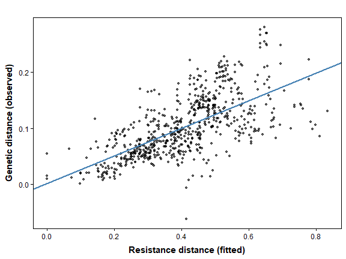

*Observed vs. resistance-distance-fitted genetic distances.*

```r
plot(fit_mlpe, type = "fit")
```

### 13.2 Fitted conductance surface

`type = "surface"` renders the point-estimate conductance surface alongside its lower and upper confidence interval bounds in a single three-panel figure. All panels share the same color scale so relative differences are easy to read:

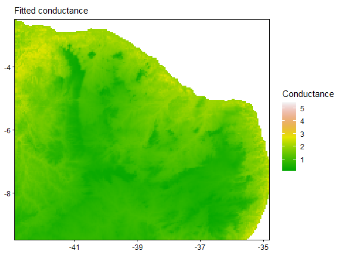

*Estimated conductance surface with 95% confidence interval bounds.*

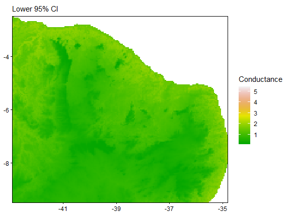

*Estimated conductance surface with 95% confidence interval bounds.*

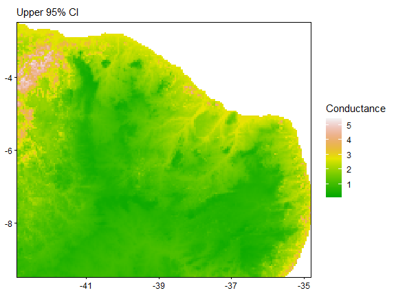

*Estimated conductance surface with 95% confidence interval bounds.*

```r
plot(fit_mlpe, type = "surface", data = surface)
```

Brighter cells have higher fitted relative conductance. Panels where the lower and upper bounds are close together indicate narrower conditional uncertainty under the fitted model; they do not directly measure movement or permeability.

### 13.3 Marginal associations with predicted genetic distance (default)

The default plot (`type = "marginal_response"`) shows how each raster covariate is associated with the **predicted genetic distance** (the response variable itself) rather than the intermediate conductance scale. Because genetic distance is the observed response that the model fits, this is usually the most directly interpretable view.

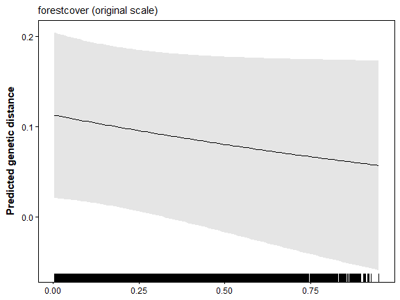

*Marginal association of each covariate with predicted genetic distance, with predictive bands.*

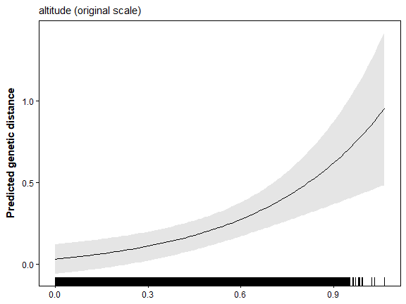

*Marginal association of each covariate with predicted genetic distance, with predictive bands.*

```r
plot(fit_mlpe, data = surface)
```

**How to read these plots**

Each panel sweeps one covariate across its observed range while all other covariates are kept at their *observed* values at every grid cell (not at a single mean value). The curve is therefore a weighted average over the actual landscape, which matters most when the associations of different covariates interact.

The **central curve** is the expected genetic distance at the given covariate value, marginalized over the rest of the landscape.

The **shaded predictive band** combines three sources of uncertainty:

1. *Theta (conductance parameter) uncertainty*: imprecision in the estimated conductance parameters $\theta$, propagated through the resistance-distance calculation via the delta method.
2. *Phi (measurement-model parameter) uncertainty*: imprecision in the nuisance parameters (intercept $\alpha$, IBR slope $\beta$, log precision $\tau$, and the unconstrained correlation parameter $\rho$), again via the delta method. The corresponding shared-site correlation is `plogis(rho) / 2`.
3. *Residual variation*: the irreducible scatter in pairwise genetic distances around the fitted mean, with variance `exp(-tau)`.

A **rising curve** means that higher covariate values are associated with higher predicted genetic distance under the fitted model. A **declining curve** means the conditional predicted association is negative. These plots do not establish a causal permeability or connectivity mechanism.

> **Note:** Quadratic terms (`I(x^2)`) and interactions (`x * z`) in the formula are handled automatically. For an interaction, each panel holds the other covariate at its observed values across all grid cells, so the curve represents the average fitted association of the focal covariate over the joint distribution of the landscape.

### 13.4 Marginal associations on the conductance scale

If you prefer to see the fitted association on the underlying conductance surface (without residual variation in the band, and on the conductance rather than genetic distance scale), use `type = "marginal"`:

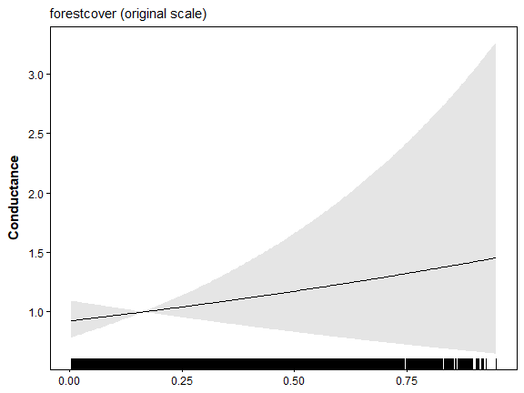

*Marginal association of each covariate with conductance, with a 95% CI.*

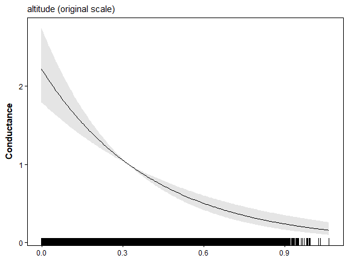

*Marginal association of each covariate with conductance, with a 95% CI.*

```r
plot(fit_mlpe, type = "marginal", data = surface)
```

Here the band is a **confidence interval** (delta-method, 95% pointwise) on the mean conductance, not a predictive interval; it reflects only parameter uncertainty in $\theta$, not residual variation. A rising curve means higher covariate values are associated with higher fitted conductance; a declining curve means the fitted conditional association is negative.

### 13.5 Support-constrained prediction and plotting

If a covariate has sparse focal support at one tail, marginal curves and conductance maps can be dominated by extrapolation. `terradish` now supports focal-support clamping directly in both `plot()` and `conductance()`:

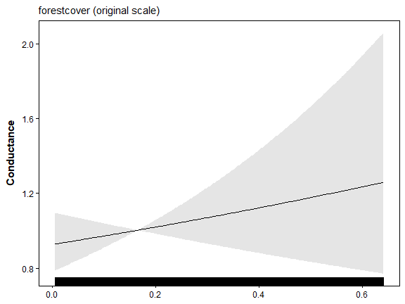

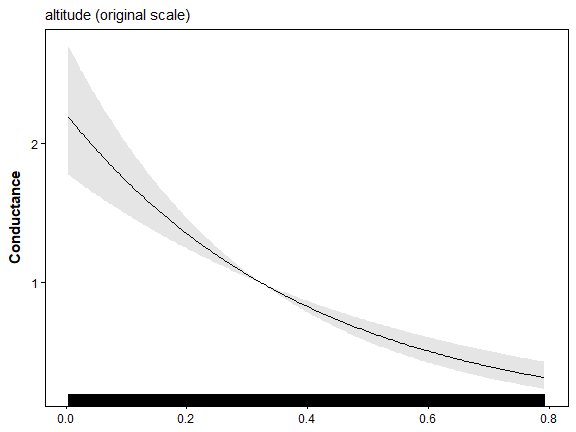

```r
# Clamp selected covariates to focal-site quantile support before plotting.
plot(
  fit_mlpe,
  type = "marginal",
  data = surface,
  support = "focal",
  support_probs = c(0.01, 0.99),
  clamp_covariates = c("altitude", "forestcover")
)
```

```r
# Apply the same support rule to raster conductance prediction.
cond_focal <- conductance(
  surface,
  fit_mlpe,
  support = "focal",
  support_probs = c(0.01, 0.99),
  clamp_covariates = c("altitude", "forestcover")
)
```

Focal support means the covariate values in the raster cells containing sampled sites. The default `support_probs = c(0, 1)` uses their minimum and maximum; the example uses their 1st and 99th percentiles. Values outside those limits are set to the nearest limit before conductance is evaluated. For splines, evaluation retains the fitted knots and basis definition.

Use `support = "none"` (default) for full-domain evaluation. Clamping with `support = "focal"` changes the displayed or predicted surface; it does not refit the likelihood, change the fitted graph, or remove uncertainty about poorly sampled environments. Report the limits and compare both maps. Predictions on new rasters must retain training transformations; use `scale_covariates(new_covariates, reference = covariates)` before building the new surface rather than scaling each domain independently.

## 14 Quick-reference: the full workflow in one block

```r
library(terradish)
library(terra)

# 1. Load data
data(melip)
melip.altitude    <- terra::unwrap(melip.altitude)
melip.forestcover <- terra::unwrap(melip.forestcover)
melip.coords      <- terra::unwrap(melip.coords)

# 2. Scale covariates and build surface
covariates <- c(melip.forestcover, melip.altitude)
names(covariates) <- c("forestcover", "altitude")
covariates <- scale_covariates(covariates)

surface <- conductance_surface(covariates, melip.coords,
                               directions = 8, saveStack = TRUE)

# 2b. (Optional) Profile graph and identify fastest settings
#     Most useful for large graphs (> 10 000 vertices) or spline models.
assessment <- terradish_assess_settings(
  melip.Fst ~ forestcover + altitude,
  data              = surface,
  conductance_model = loglinear_conductance,
  measurement_model = mlpe,
  probe_maxit       = 2
)
cat(assessment$comparison$summary, "\n")  # one-line verdict
rec <- assessment$recommended             # reuse for all fits below

# 3. Fit model - choose a measurement model:
#   leastsquares      : fast, independent errors (distance matrix)
#   mlpe              : shared-site correlation correction (distance matrix)
#   generalized_wishart: Wishart model for an admissible squared-distance response;
#                        requires nu
#   wishart_covariance : Wishart model, requires nu (covariance matrix)
#   For Wishart IBE or site-level environmental covariance kernels, use
#   wishart_covariates().
fit <- terradish(melip.Fst ~ forestcover + altitude,
                 data              = surface,
                 conductance_model = loglinear_conductance,
                 measurement_model = mlpe,
                 optimizer         = rec$optimizer,
                 control           = rec$control,
                 solver            = rec$solver,
                 solver_control    = rec$solver_control,
                 approximation     = rec$approximation,
                 approximation_control = rec$approximation_control)

# For generalized_wishart, derive and check a squared-distance response:
# S_cov <- cov_from_genetic_data(genotype_matrix, groups = population)
# S_dist <- dist_from_cov(S_cov)
# check_distance_response(S_dist)
# fit_gw <- terradish(S_dist ~ forestcover + altitude, data = surface,
#                     conductance_model = loglinear_conductance,
#                     measurement_model = generalized_wishart,
#                     nu = effective_marker_df)

# 4. Summarize and visualize
summary(fit)

plot(fit, type = "fit")                                # observed vs. fitted scatter
plot(fit, type = "surface", data = surface)            # conductance map + 95% CI panels
plot(fit, data = surface)                              # marginal associations on genetic distance (default)
plot(fit, type = "marginal", data = surface)           # marginal associations on conductance scale

# 5. Optional: focal-support clamping for robust tails
plot(fit, type = "marginal", data = surface,
     support = "focal", support_probs = c(0.01, 0.99),
     clamp_covariates = c("forestcover", "altitude"))

cond <- conductance(surface, fit,
                    support = "focal", support_probs = c(0.01, 0.99),
                    clamp_covariates = c("forestcover", "altitude"))
```

## 15 Summary of key functions

| Function | Purpose |
| --- | --- |
| `scale_covariates()` | Center and scale raster layers to mean 0, sd 1 before fitting |
| `scale_to_0_1()` | Rescale layers to the unit interval |
| `crop_to_focal_buffer()` | Trim the raster extent to a buffer around the focal sites |
| `conductance_surface()` | Build the weighted graph linking raster cells and focal sites |
| `terradish_assess_settings()` | Profile the graph and recommend solver and optimizer settings |
| `terradish()` | Fit the model by maximum likelihood |
| `loglinear_conductance()` | Default conductance model, `c = exp(X theta)` |
| `leastsquares()`, `mlpe()` | Measurement models for a genetic distance matrix |
| `check_distance_response()` | Diagnose squared-Euclidean admissibility before a generalized-Wishart fit |
| `generalized_wishart()`, `wishart_covariance()` | Wishart models for squared-distance and covariance responses, respectively; both need `nu` |
| `summary()`, `coef()`, `confint()` | Estimates, standard errors, and intervals on the log-conductance scale |
| `plot()` | Observed vs. fitted, conductance surface, and marginal associations |
| `conductance()` | Extract the fitted conductance surface as a `SpatRaster` |